# Randomized Blocks, Latin Squares, and Related Designs

# Example 4.1

Example 4.1 describes an experiment where batches of resin are extruded at different pressures and the proportion of defective grafts are recorded. The goal of the experiment is to maximize yield by minimizing the number of defects (`Flicks`). The structure of the data is presented below.

```r
str(Table4.3)
# 'data.frame': 24 obs. of  3 variables:
#  $ ExtrusionPressure: Factor w/ 4 levels "8500","8700",..: 1 2 3 4 1 2 3 4 1 2 ...
#  $ BatchOfResin     : Factor w/ 6 levels "1","2","3","4",..: 1 1 1 1 2 2 2 2 3 3 ...
#  $ Flicks           : num  90.3 92.5 85.5 82.5 89.2 89.5 90.8 89.5 98.2 90.6 ...
```

In generating the ANOVA table we can either include `BatchOfResin` and ignore the $p$-value or we can mark it with `Error` to indicate each level is a block.

```r
model <- aov(Flicks ~ Error(BatchOfResin) + ExtrusionPressure, data=Table4.3)
print(summary(model))
#
# Error: BatchOfResin
#           Df Sum Sq Mean Sq F value Pr(>F)
# Residuals  5  192.2   38.45
#
# Error: Within
#                   Df Sum Sq Mean Sq F value  Pr(>F)
# ExtrusionPressure  3  178.2   59.39   8.107 0.00192 **
# Residuals         15  109.9    7.33
# ---
# Signif. codes:  0 '***' 0.001 '**' 0.01 '*' 0.05 '.' 0.1 ' ' 1
```

What if we hadn’t recognized that this was a completely randomized block design? That would yield the following ANOVA table.

```r
summary(aov(Flicks ~ ExtrusionPressure, data=Table4.3))
#                   Df Sum Sq Mean Sq F value Pr(>F)
# ExtrusionPressure  3  178.2   59.39   3.931 0.0234 *
# Residuals         20  302.1   15.11
# ---
# Signif. codes:  0 '***' 0.001 '**' 0.01 '*' 0.05 '.' 0.1 ' ' 1
```

To estimate the means we turn to the `emmeans` package (Lenth et al. 2019).

```r
library(emmeans)
model <- aov(Flicks ~ ExtrusionPressure + BatchOfResin, data=Table4.3)
exmodel <- emmeans(model, ~ ExtrusionPressure)
print(exmodel)
#  ExtrusionPressure emmean  SE df lower.CL upper.CL
#  8500                92.8 1.1 15     90.5     95.2
#  8700                91.7 1.1 15     89.3     94.0
#  8900                88.9 1.1 15     86.6     91.3
#  9100                85.8 1.1 15     83.4     88.1
#
# Results are averaged over the levels of: BatchOfResin
# Confidence level used: 0.95
blmodel <- emmeans(model, ~ BatchOfResin)
print(blmodel)
#  BatchOfResin emmean   SE df lower.CL upper.CL
#  1              87.7 1.35 15     84.8     90.6
#  2              89.8 1.35 15     86.9     92.6
#  3              91.0 1.35 15     88.1     93.9
#  4              90.5 1.35 15     87.7     93.4
#  5              85.3 1.35 15     82.4     88.2
#  6              94.5 1.35 15     91.6     97.3
#
# Results are averaged over the levels of: ExtrusionPressure
# Confidence level used: 0.95
```

We follow this with a boxplot for the defects.

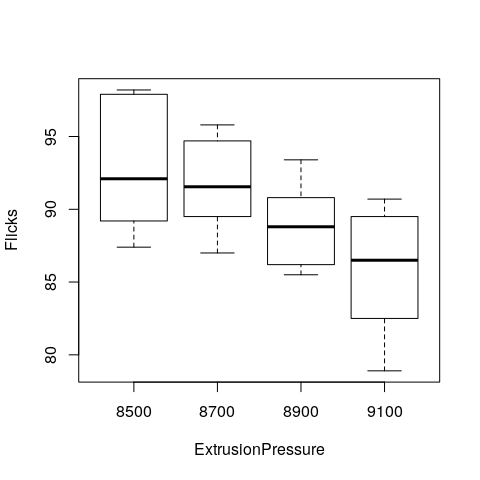

```r
boxplot(Flicks ~ ExtrusionPressure, data=Table4.3)
```

Consider the diagnostic plots for Example 4.1.

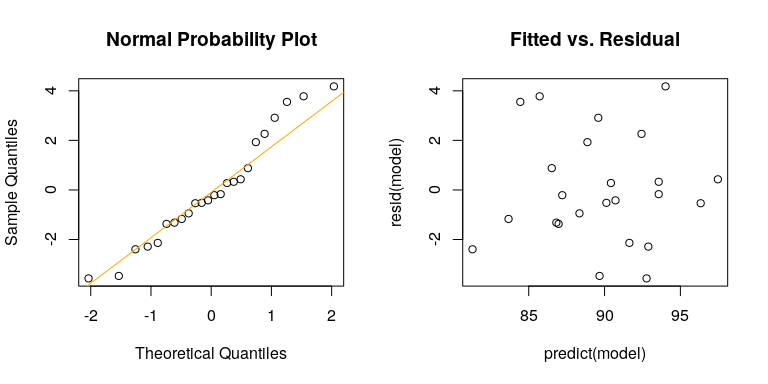

```r
op <- par(mfrow=c(1,2))
qqnorm(resid(model), main='Normal Probability Plot')
qqline(resid(model), col='orange')
plot(x=predict(model), y=resid(model), main='Fitted vs. Residual')
```

```r
par(op)
```

The plot of residual versus each of the factors would be informative if some model misspecificaiton had occurred, but as in Figure 4.6, we find no strong evidence of problems from such a plot.

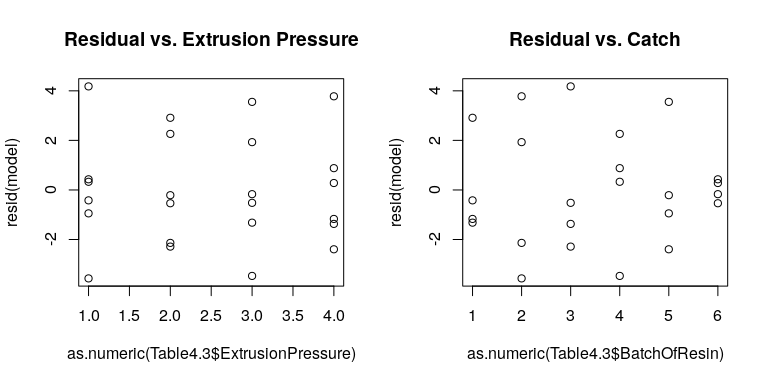

```r
op <- par(mfrow=c(1,2))
plot(y=resid(model), x=as.numeric(Table4.3$ExtrusionPressure), main='Residual vs. Extrusion Pressure')
plot(y=resid(model), x=as.numeric(Table4.3$BatchOfResin), main='Residual vs. Catch')
```

```r
par(op)
```

Let’s assume the blocks are random effects, then we arrive at the following model.

```r
library(lme4)
library(lmerTest)
model <- lmer(
    Flicks ~ -1 + ExtrusionPressure + (1|BatchOfResin),
    data=Table4.3,
    REML=TRUE
)
print(summary(model))
# Linear mixed model fit by REML. t-tests use Satterthwaite's method [
# lmerModLmerTest]
# Formula: Flicks ~ -1 + ExtrusionPressure + (1 | BatchOfResin)
#    Data: Table4.3
#
# REML criterion at convergence: 112
#
# Scaled residuals:
#      Min       1Q   Median       3Q      Max
# -1.32253 -0.64269  0.01068  0.54202  1.62882
#
# Random effects:
#  Groups       Name        Variance Std.Dev.
#  BatchOfResin (Intercept) 7.781    2.789
#  Residual                 7.326    2.707
# Number of obs: 24, groups:  BatchOfResin, 6
#
# Fixed effects:
#                       Estimate Std. Error     df t value Pr(>|t|)
# ExtrusionPressure8500   92.817      1.587 11.136   58.49 3.24e-15 ***
# ExtrusionPressure8700   91.683      1.587 11.136   57.78 3.71e-15 ***
# ExtrusionPressure8900   88.917      1.587 11.136   56.04 5.22e-15 ***
# ExtrusionPressure9100   85.767      1.587 11.136   54.05 7.79e-15 ***
# ---
# Signif. codes:  0 '***' 0.001 '**' 0.01 '*' 0.05 '.' 0.1 ' ' 1
#
# Correlation of Fixed Effects:
#             EP8500 EP8700 EP8900
# ExtrsnP8700 0.515
# ExtrsnP8900 0.515  0.515
# ExtrsnP9100 0.515  0.515  0.515
print(rand(model))
# ANOVA-like table for random-effects: Single term deletions
#
# Model:
# Flicks ~ ExtrusionPressure + (1 | BatchOfResin) - 1
#                    npar  logLik    AIC    LRT Df Pr(>Chisq)
# <none>                6 -56.021 124.04
# (1 | BatchOfResin)    5 -59.114 128.23 6.1853  1    0.01288 *
# ---
# Signif. codes:  0 '***' 0.001 '**' 0.01 '*' 0.05 '.' 0.1 ' ' 1
```

Confidence intervals on the variance components and the fixed effects can also be evaluated.

```r
confint(model, oldNames=FALSE)
#                                 2.5 %    97.5 %
# sd_(Intercept)|BatchOfResin  1.136322  5.540193
# sigma                        1.840242  3.564370
# ExtrusionPressure8500       89.726101 95.907233
# ExtrusionPressure8700       88.592767 94.773900
# ExtrusionPressure8900       85.826101 92.007233
# ExtrusionPressure9100       82.676101 88.857233
```

# Example 4.2

In Example 4.2 an experimenter is studying the effects five different formulation of rocket propellant on the burn rate of that propellant (see Table 4.9 in the textbook). Formulations are constructed from batches that can only supply five formulations in all. Also, the formulations are prepared by different operators. The two levels of blocking - the batch and the operator - require the use of a Latin square design. First, let’s look at the structure of the data.

```r
str(Table4.9)
# 'data.frame': 25 obs. of  4 variables:
#  $ Batch      : Factor w/ 5 levels "1","2","3","4",..: 1 2 3 4 5 1 2 3 4 5 ...
#  $ Operator   : Factor w/ 5 levels "1","2","3","4",..: 1 1 1 1 1 2 2 2 2 2 ...
#  $ Formulation: Factor w/ 5 levels "A","B","C","D",..: 1 2 3 4 5 2 3 4 5 1 ...
#  $ BurnRate   : num  24 17 18 26 22 20 24 38 31 30 ...
```

Next, let’s conduct the ANOVA test to see if `Formulation` has an effect. Again, wrapping `Batch` and `Operator` in `Error` is optional and just prevents rendering $p$-values for them.

```r
y <- Table4.9$BurnRate - 25
model <- aov(y ~ Error(Batch + Operator) + Formulation, data=Table4.9)
summary(model)
#
# Error: Batch
#           Df Sum Sq Mean Sq F value Pr(>F)
# Residuals  4     68      17
#
# Error: Operator
#           Df Sum Sq Mean Sq F value Pr(>F)
# Residuals  4    150    37.5
#
# Error: Within
#             Df Sum Sq Mean Sq F value  Pr(>F)
# Formulation  4    330   82.50   7.734 0.00254 **
# Residuals   12    128   10.67
# ---
# Signif. codes:  0 '***' 0.001 '**' 0.01 '*' 0.05 '.' 0.1 ' ' 1
```

In this situation the design was provided, but you can use R to find Latin squares and Graeco-Latin squares. The package `agricolae` (Mendiburu 2019) contains functions for finding such designs. Constructing a Latin square can be done with `design.lsd`:

```r
library(agricolae)

trt <- c("A", "B", "C", "D")
outdesign <- design.lsd(trt)
print(outdesign$sketch)
#      [,1] [,2] [,3] [,4]
# [1,] "A"  "B"  "C"  "D"
# [2,] "D"  "A"  "B"  "C"
# [3,] "C"  "D"  "A"  "B"
# [4,] "B"  "C"  "D"  "A"
```

The `agricolae` package can also be used to construct Graeco-Latin squares with `design.graeco` and a host of other designs (balanced incomplete block designs, split plots, strip plots, etc.).

# Example 4.3

In Example 4.3 the rocket propellant data is analyzed with an additional blocking factor: `TestAssembly`.

```r
y <- Table4.20$BurnRate - 25
model <- aov(y ~ Error(Batch + Operator + TestAssembly) + Formulation, data=Table4.20)
summary(model)
#
# Error: Batch
#           Df Sum Sq Mean Sq F value Pr(>F)
# Residuals  4     68      17
#
# Error: Operator
#           Df Sum Sq Mean Sq F value Pr(>F)
# Residuals  4    150    37.5
#
# Error: TestAssembly
#           Df Sum Sq Mean Sq F value Pr(>F)
# Residuals  4     62    15.5
#
# Error: Within
#             Df Sum Sq Mean Sq F value  Pr(>F)
# Formulation  4    330   82.50      10 0.00334 **
# Residuals    8     66    8.25
# ---
# Signif. codes:  0 '***' 0.001 '**' 0.01 '*' 0.05 '.' 0.1 ' ' 1
```

# Section 4.4 - Balanced Incomplete Block Design

The data in Table 4.22 in the textbook is from an experiment when an engineer tests four types of catalyst to optimize reaction time. Batches of material are only enough for three runs, so we must treat the batches as blocks. This is a balanced incomplete block design, and is not orthogonal. Because of this `ReactionTime ~ Batch + Catalyst` and `ReactionTime ~ Catalyst + Batch` give different results. Taking `Batch` before `Catalyst` adjusts `Catalyst` for the effect of `Batch`. This is what we want.

```r
model <- aov(ReactionTime ~ Batch + Catalyst, data=Table4.22)
summary(model)
#             Df Sum Sq Mean Sq F value  Pr(>F)
# Batch        3  55.00  18.333   28.20 0.00147 **
# Catalyst     3  22.75   7.583   11.67 0.01074 *
# Residuals    5   3.25   0.650
# ---
# Signif. codes:  0 '***' 0.001 '**' 0.01 '*' 0.05 '.' 0.1 ' ' 1
```

Compare this to the other order and we get the unadjusted treatment and adjusted block in Table 4.25.

```r
model <- aov(ReactionTime ~ Catalyst + Batch, data=Table4.22)
summary(model)
#             Df Sum Sq Mean Sq F value   Pr(>F)
# Catalyst     3  11.67   3.889   5.983 0.041463 *
# Batch        3  66.08  22.028  33.889 0.000953 ***
# Residuals    5   3.25   0.650
# ---
# Signif. codes:  0 '***' 0.001 '**' 0.01 '*' 0.05 '.' 0.1 ' ' 1
```

Interestingly, if you wrap `Batch` with `Error` then R evaluates it first and the order does not matter.

Let’s fit a model for parameter estimation. I’m going to use `emmeans` so we can’t use the `Error` function.

```r
library(emmeans)
model <- aov(ReactionTime ~ Batch + Catalyst, Table4.22)
print(summary(model))
#             Df Sum Sq Mean Sq F value  Pr(>F)
# Batch        3  55.00  18.333   28.20 0.00147 **
# Catalyst     3  22.75   7.583   11.67 0.01074 *
# Residuals    5   3.25   0.650
# ---
# Signif. codes:  0 '***' 0.001 '**' 0.01 '*' 0.05 '.' 0.1 ' ' 1
camodel <- emmeans(model, ~Catalyst)
print(camodel)
#  Catalyst emmean    SE df lower.CL upper.CL
#  1          71.4 0.487  5     70.1     72.6
#  2          71.6 0.487  5     70.4     72.9
#  3          72.0 0.487  5     70.7     73.3
#  4          75.0 0.487  5     73.7     76.3
#
# Results are averaged over the levels of: Batch
# Confidence level used: 0.95
bamodel <- emmeans(model, ~Batch)
print(bamodel)
#  Batch emmean    SE df lower.CL upper.CL
#  1       73.4 0.487  5     72.1     74.6
#  2       75.5 0.487  5     74.2     76.8
#  3       68.6 0.487  5     67.4     69.9
#  4       72.5 0.487  5     71.2     73.8
#
# Results are averaged over the levels of: Catalyst
# Confidence level used: 0.95
print(pairs(camodel, adjust='tukey'))
#  contrast estimate    SE df t.ratio p.value
#  1 - 2      -0.250 0.698  5 -0.358  0.9825
#  1 - 3      -0.625 0.698  5 -0.895  0.8085
#  1 - 4      -3.625 0.698  5 -5.192  0.0130
#  2 - 3      -0.375 0.698  5 -0.537  0.9462
#  2 - 4      -3.375 0.698  5 -4.834  0.0175
#  3 - 4      -3.000 0.698  5 -4.297  0.0281
#
# Results are averaged over the levels of: Batch
# P value adjustment: tukey method for comparing a family of 4 estimates
```

# References

Lenth, Russell, Henrik Singmann, Jonathon Love, Paul Buerkner, and Maxime Herve. 2019. *Emmeans: Estimated Marginal Means, Aka Least-Squares Means*. https://cran.r-project.org/package=emmeans.

Mendiburu, Felipe de. 2019. *Agricolae: Statistical Procedures for Agricultural Research*. https://cran.r-project.org/package=agricolae.